# Work Hour Communication Analysis

Onifade Monsuru

2024-07-16

# Introduction

Effective communication is crucial for any organization’s success. With the rise of digital communication, emails have become a vital tool for exchanging information and collaborating among team members. Analyzing email communication patterns can provide valuable insights into organizational dynamics, productivity, and employee behavior. This project aims to investigate the communication patterns during work hours, focusing on email exchanges between executives, departments, and devices used. The analysis will uncover trends, sentiment, and preferences, providing actionable recommendations for enhancing communication and productivity within the organization.

# Executive Summary

This report presents the findings of the **Work Hour Communication Analysis project**, which examined email communication patterns during work hours. Key takeaways include: **Email was exchanged between 47 individuals**

**Sender Profiles**

- Top sender roles: C-level **287(25%)**, Middle level management **345(31%)**, Professional **500 (44%)**

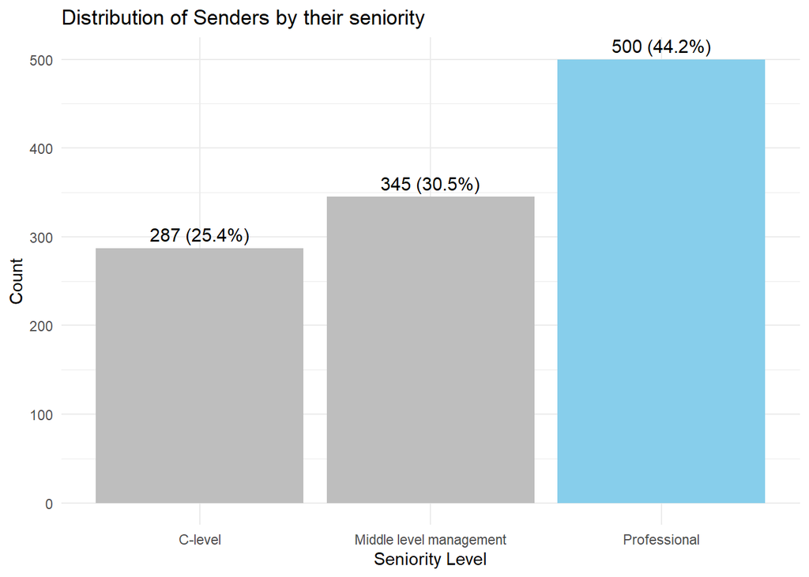

- Top sender departments: Executive Management **287(25.4%)**, Marketing **146(12.9%)**, Product Development **133(11.7%)**

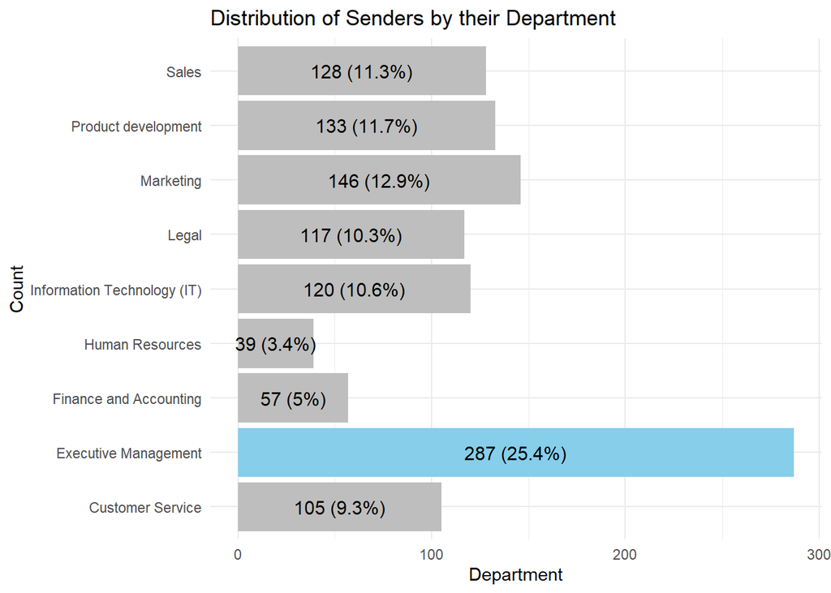

**Recipient Profiles**

- Top recipient roles: C-level **48(4%)**, Middle level management **435(39%)**, Professional **649(57%)**

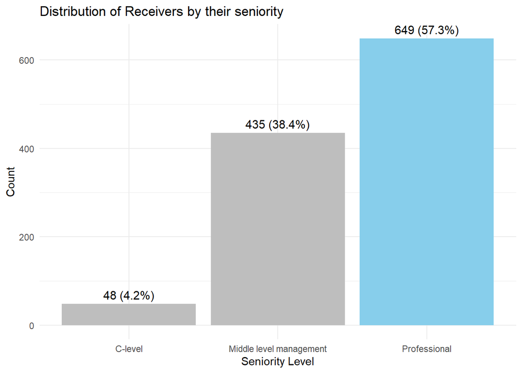

- Top recipient departments: Product Development **205(18.1%)**, **Marketing (14.5%)**, **Sales(14.1%)**

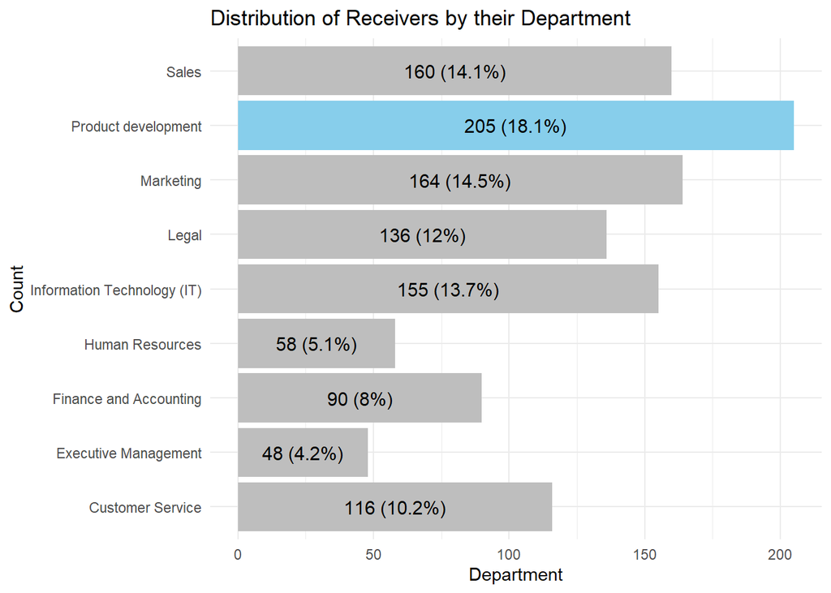

**Email Topics**

- 14 unique topics
- Top topics: **Sales and Marketing 131(11.57%)**, **Legal matters 128(11.31%)**, **Meeting Scheduling 126(11.13%)**

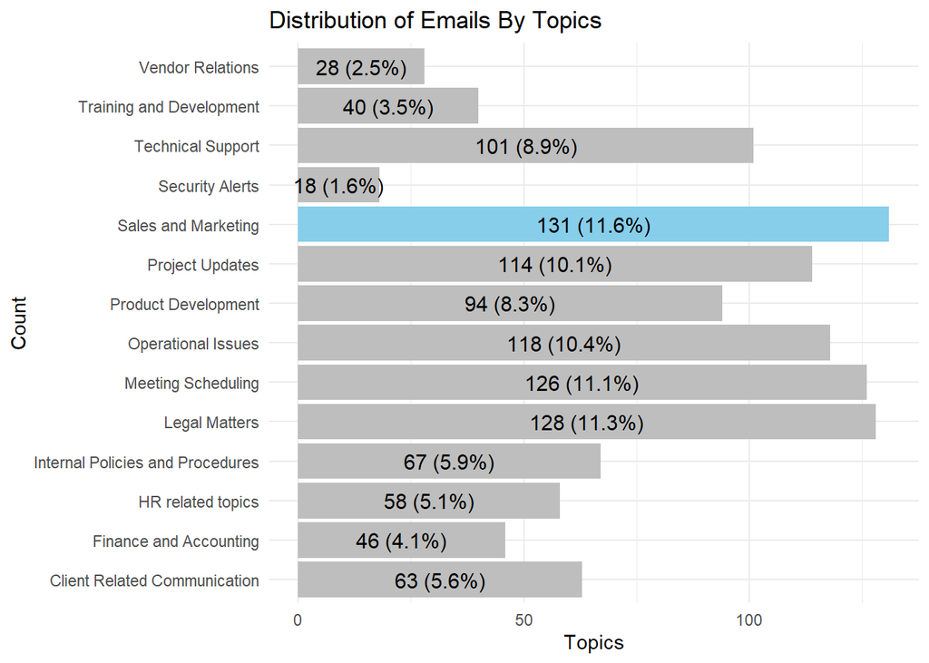

**Email Sentiment**

- Neutral 660(58.3%), Positive 353(31.18%), Negative 119(10.51%)

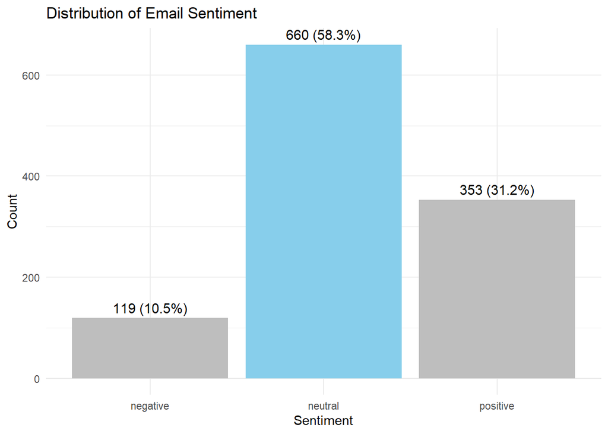

**Email Open and Device Usage**

- Opened: 1034(91.3%), Unopened: 98(8.7%)

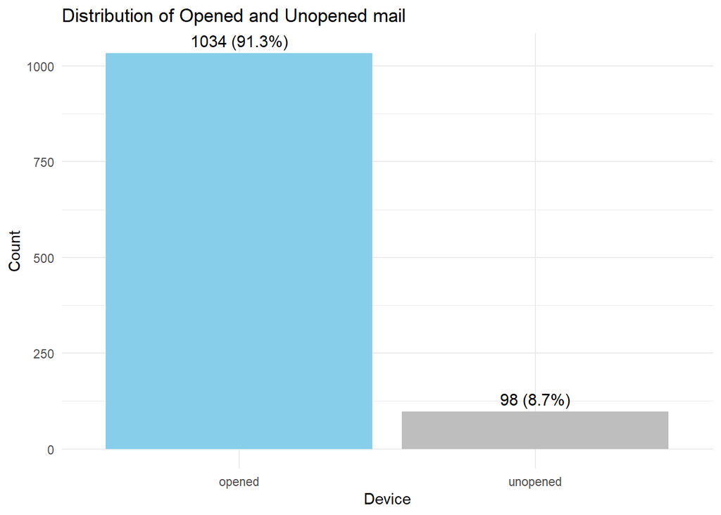

- Desktop: 860(76%), Mobile: 272(24%)

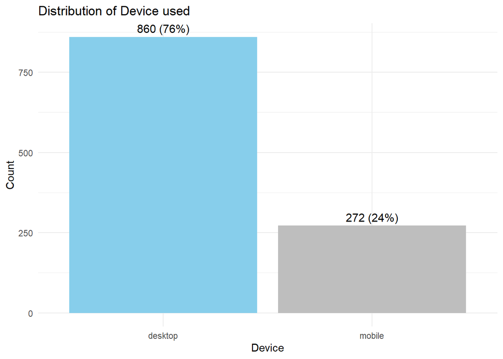

**Work Hour and Workday Analysis**

- Emails sent within work hours: 912(80.6%)

[figure not shown]

- Emails sent within workdays: 1066(94.2%)

[figure not shown]

The report provides a comprehensive analysis of communication patterns, sentiment, and device usage during work hours. The insights and recommendations offered can help optimize email communication, enhance productivity, and inform future organizational strategies.

# EXPLORATORY DATA ANALYSIS

## Communication Patterns During Work Hours

**What are the most common email topics discussed during work hours?**

**Sales and Marketing (105) is the most discusssed topic during the work hour**

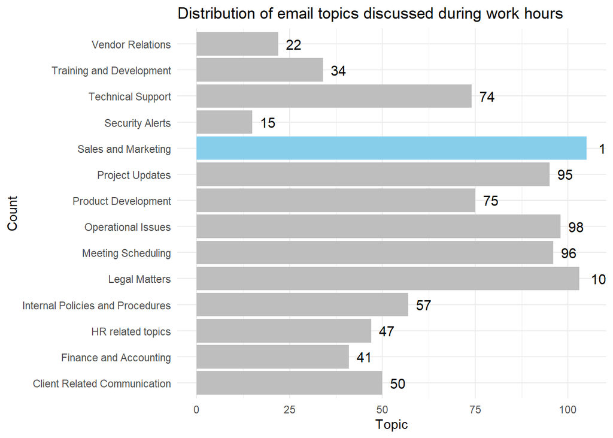

### Key Insights

-The most commmon email topic (Sales and Marketing) discussed was mostly sent or received by the **Professionals** during the work hour.

-The sentiment of the most commmon email topic (Sales and Marketing) was **neutral**.

-The device mostly used to send or receive the most commmon email topic (Sales and Marketing) was **desktop**.

-Emails with this topic are mostly sent/received by the marketing department.

## Executive Communication During Work Hours

**How many emails do C-level executives send and receive during work hours?**

**C-level executives send(233) and receive(41) mails during work hours**

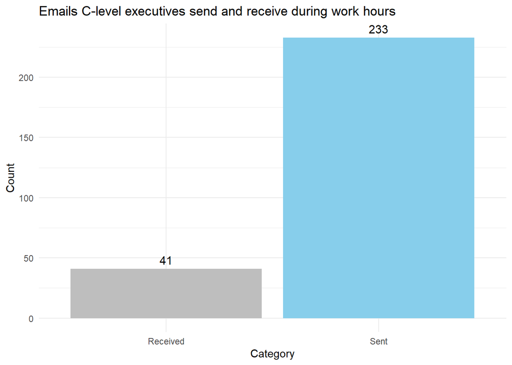

### Key Insights

-The most common topics discussed by C-level executives during work hours are **Product Development(34), Meeting Scheduling(28),Sales and Marketing(26)** and others .

-During work hours, C-level executives tend to communicate more with the following departments;**Product development(58), Executive Management(41),Finance and Accounting(31)** and others .

-During work hours, C-level executive emails more likely to have a **neutral(144), positive(67) and negative(22) sentiments**.

[output not shown]